# ANOVA test for registro_formal

Geiser C. Challco geiser@alumni.usp.br

- ANOVA: registro_formal ~ time
  - Data Preparation
  - Summary Statistics
  - ANOVA Computation
  - PairWise Computation
- ANOVA: registro_formal ~ time*gender + Error(id/time)
  - Data Preparation
    - Check assumptions: Identifying Outliers
    - Check assumptions: Normality Test
    - Summary Statistics
  - ANOVA Computation
  - ANOVA Computation after removing non.normal data
  - PairWise Computation
  - PairWise Computation after removing non.normal data
- ANOVA: registro_formal ~ time*localizacao + Error(id/time)
  - Data Preparation
    - Check assumptions: Identifying Outliers
    - Check assumptions: Normality Test
    - Summary Statistics
  - ANOVA Computation
  - ANOVA Computation after removing non.normal data
  - PairWise Computation
  - PairWise Computation after removing non.normal data
- ANOVA: registro_formal ~ time*regiao + Error(id/time)
  - Data Preparation
    - Check assumptions: Identifying Outliers
    - Check assumptions: Normality Test
    - Summary Statistics
  - ANOVA Computation
  - ANOVA Computation after removing non.normal data
  - PairWise Computation
  - PairWise Computation after removing non.normal data
- ANOVA: registro_formal ~ time*porte + Error(id/time)
  - Data Preparation
    - Check assumptions: Identifying Outliers
    - Check assumptions: Normality Test
    - Summary Statistics
  - ANOVA Computation
  - ANOVA Computation after removing non.normal data
  - PairWise Computation
  - PairWise Computation after removing non.normal data

```r
dat <- read_excel("../data/data.xlsx", sheet = "alunos_ef59")

escolas <- read_excel("../data/data.xlsx", sheet = "escolas")
edat <- merge(dat, escolas, by = "cod_escola", all.x = T)
```

# ANOVA: registro_formal ~ time

## Data Preparation

```r
data <- edat[,c("aluno_id","ciclo","registro_formal")]
data <- data[data$ciclo %in% c("Segundo Ciclo","Terceiro Ciclo"),]
data$ciclo <- factor(data$ciclo, c("Segundo Ciclo","Terceiro Ciclo"))
data <- unique(data)

wdat <- spread(data, ciclo, registro_formal)
wdat <- wdat[complete.cases(wdat),]
colnames(wdat) <- c("id","c2","c3")

ldat <- gather(wdat, key = time, value = registro_formal, c2,c3) %>%
  convert_as_factor(id, time)
ldat <- rshinystatistics::remove_group_data(ldat, "registro_formal", "time", n.limit = 30)
```

## Summary Statistics

```r
(sdat <- ldat %>% group_by(time) %>%
   get_summary_stats(registro_formal, type = "mean_sd"))
```

```
## # A tibble: 2 × 5
##   time  variable            n  mean    sd
##   <fct> <fct>           <dbl> <dbl> <dbl>
## 1 c2    registro_formal  4042  1.81 0.676
## 2 c3    registro_formal  4042  1.89 0.768
```

| time | variable | n | mean | sd |
| --- | --- | --- | --- | --- |
| c2 | registro_formal | 4042 | 1.811 | 0.676 |
| c3 | registro_formal | 4042 | 1.890 | 0.768 |

## ANOVA Computation

```r
(res.aov <- anova_test(ldat, dv = registro_formal, wid = id, within = time))
```

```
## ANOVA Table (type III tests)
##
##   Effect DFn  DFd      F        p p<.05   ges
## 1   time   1 4041 28.551 9.63e-08     * 0.003
```

## PairWise Computation

```r
(pwc <- ldat %>% emmeans_test(registro_formal ~ time, detailed = T, p.adjust.method = "bonferroni"))
```

```
## # A tibble: 1 × 14
##   term  .y.    group1 group2 null.value estimate     se    df conf.low conf.high
## * <chr> <chr>  <chr>  <chr>       <dbl>    <dbl>  <dbl> <dbl>    <dbl>     <dbl>
## 1 time  regis… c2     c3              0  -0.0797 0.0161  8082   -0.111   -0.0482
## # ℹ 4 more variables: statistic <dbl>, p <dbl>, p.adj <dbl>, p.adj.signif <chr>
```

| term | .y. | group1 | group2 | null.value | estimate | se | df | conf.low | conf.high | statistic | p | p.adj | p.adj.signif |
| --- | --- | --- | --- | --- | --- | --- | --- | --- | --- | --- | --- | --- | --- |
| time | registro_formal | c2 | c3 | 0 | -0.08 | 0.016 | 8082 | -0.111 | -0.048 | -4.952 | 0 | 0 | **** |

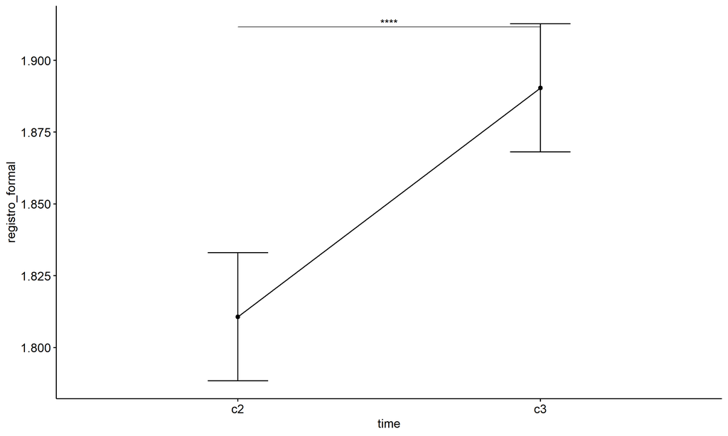

```r
pwc <- add_xy_position(pwc, x = "time", fun = "mean_se")
ggline(get_emmeans(pwc), x = "time", y = "emmean", ylab = "registro_formal") +
  geom_errorbar(aes(ymin = conf.low, ymax = conf.high), width = 0.2) +
  stat_pvalue_manual(pwc, hide.ns = T, tip.length = F)
```

# ANOVA: registro_formal ~ time*gender + Error(id/time)

## Data Preparation

```r
data <- edat[,c("aluno_id","gender","ciclo","registro_formal")]
data <- data[data$ciclo %in% c("Segundo Ciclo","Terceiro Ciclo"),]
data$ciclo <- factor(data$ciclo, c("Segundo Ciclo","Terceiro Ciclo"))
data <- unique(data)

wdat <- spread(data, ciclo, registro_formal)
wdat <- wdat[complete.cases(wdat),]
colnames(wdat) <- c("id","gender","c2","c3")

ldat <- gather(wdat, key = time, value = registro_formal, c2,c3) %>%
  convert_as_factor(id, time)
ldat <- remove_group_data(ldat, "registro_formal", c("time", "gender"), n.limit = 30)
ldat$gender <- factor(ldat$gender, sort(unique(ldat$gender)))
```

### Check assumptions: Identifying Outliers

```r
outliers <- identify_outliers(group_by(ldat, time, gender), registro_formal)
(outliers <- outliers[outliers$is.extreme == T,])
```

```
## # A tibble: 0 × 6
## # ℹ 6 variables: gender <fct>, time <fct>, id <fct>, registro_formal <dbl>,
## #   is.outlier <lgl>, is.extreme <lgl>
```

| gender | time | id | registro_formal | is.outlier | is.extreme |
| --- | --- | --- | --- | --- | --- |

### Check assumptions: Normality Test

```r
(normality.df <- normality.test.per.groups(ldat, "registro_formal", c("time", "gender")))
```

```
##               var        variable time gender    n  skewness    kurtosis
## 1 registro_formal registro_formal   c2 Female 1876 0.5946100  0.18242297
## 2 registro_formal registro_formal   c2   Male 1917 0.7191437  0.31946348
## 3 registro_formal registro_formal   c3 Female 1876 0.5650589 -0.09377792
## 4 registro_formal registro_formal   c3   Male 1917 0.6597560 -0.04995649
##   symmetry statistic     method p p.signif normality
## 1       NO  98.74899 D'Agostino 0     ****         -
## 2       NO 142.66881 D'Agostino 0     ****         -
## 3       NO  88.54288 D'Agostino 0     ****         -
## 4       NO 117.68648 D'Agostino 0     ****         -
```

| var | variable | time | gender | n | skewness | kurtosis | symmetry | statistic | method | p | p.signif | normality |
| --- | --- | --- | --- | --- | --- | --- | --- | --- | --- | --- | --- | --- |
| registro_formal | registro_formal | c2 | Female | 1876 | 0.595 | 0.182 | NO | 98.749 | D’Agostino | 0 | **** | - |
| registro_formal | registro_formal | c2 | Male | 1917 | 0.719 | 0.319 | NO | 142.669 | D’Agostino | 0 | **** | - |
| registro_formal | registro_formal | c3 | Female | 1876 | 0.565 | -0.094 | NO | 88.543 | D’Agostino | 0 | **** | - |
| registro_formal | registro_formal | c3 | Male | 1917 | 0.660 | -0.050 | NO | 117.686 | D’Agostino | 0 | **** | - |

```r
(non.ids <- unique(do.call(
  c, lapply(which(normality.df$normality == 'NO'), FUN = function(i) {
  idx = which(ldat$time == normality.df$time[i] &
                ldat$gender == normality.df$gender[i])
  getNonNormal(ldat$"registro_formal"[idx], ldat$id[idx])
}))))
```

```r
if (length(non.ids) > 0)
  ldat2 <- ldat[!ldat$id %in% non.ids,]
```

### Summary Statistics

```r
(sdat <- ldat %>% group_by(time, gender) %>%
   get_summary_stats(registro_formal, type = "mean_sd"))
```

```
## # A tibble: 4 × 6
##   gender time  variable            n  mean    sd
##   <fct>  <fct> <fct>           <dbl> <dbl> <dbl>
## 1 Female c2    registro_formal  1876  1.85 0.672
## 2 Male   c2    registro_formal  1917  1.78 0.679
## 3 Female c3    registro_formal  1876  1.94 0.768
## 4 Male   c3    registro_formal  1917  1.85 0.766
```

| gender | time | variable | n | mean | sd |
| --- | --- | --- | --- | --- | --- |
| Female | c2 | registro_formal | 1876 | 1.846 | 0.672 |
| Male | c2 | registro_formal | 1917 | 1.780 | 0.679 |
| Female | c3 | registro_formal | 1876 | 1.935 | 0.768 |
| Male | c3 | registro_formal | 1917 | 1.852 | 0.766 |

```r
if (length(non.ids) > 0)
  (sdat <- ldat2 %>% group_by(time, gender) %>%
      get_summary_stats(registro_formal, type = "mean_sd"))
```

| gender | time | variable | n | mean | sd |
| --- | --- | --- | --- | --- | --- |
| Female | c2 | registro_formal | 1876 | 1.846 | 0.672 |
| Male | c2 | registro_formal | 1917 | 1.780 | 0.679 |
| Female | c3 | registro_formal | 1876 | 1.935 | 0.768 |
| Male | c3 | registro_formal | 1917 | 1.852 | 0.766 |

## ANOVA Computation

```r
(res.aov <- anova_test(ldat, dv = registro_formal, wid = id, between = gender, within = time))
```

```
## ANOVA Table (type III tests)
##
##        Effect DFn  DFd      F        p p<.05      ges
## 1      gender   1 3791 17.660 2.70e-05     * 3.00e-03
## 2        time   1 3791 27.444 1.71e-07     * 3.00e-03
## 3 gender:time   1 3791  0.332 5.64e-01       3.76e-05
```

## ANOVA Computation after removing non.normal data

```r
if (length(non.ids) > 0)
  (res.aov2 <- anova_test(ldat2, dv = registro_formal, wid = id, between = gender , within = time))
```

## PairWise Computation

```r
(pwc <- ldat %>% group_by(time) %>%
   emmeans_test(registro_formal ~ gender, detailed = T, p.adjust.method = "bonferroni"))
```

```
## # A tibble: 2 × 15
##   time  term   .y.       group1 group2 null.value estimate     se    df conf.low
## * <fct> <chr>  <chr>     <chr>  <chr>       <dbl>    <dbl>  <dbl> <dbl>    <dbl>
## 1 c2    gender registro… Female Male            0   0.0657 0.0235  7582   0.0197
## 2 c3    gender registro… Female Male            0   0.0834 0.0235  7582   0.0374
## # ℹ 5 more variables: conf.high <dbl>, statistic <dbl>, p <dbl>, p.adj <dbl>,
## #   p.adj.signif <chr>
```

| time | term | .y. | group1 | group2 | null.value | estimate | se | df | conf.low | conf.high | statistic | p | p.adj | p.adj.signif |
| --- | --- | --- | --- | --- | --- | --- | --- | --- | --- | --- | --- | --- | --- | --- |
| c2 | gender | registro_formal | Female | Male | 0 | 0.066 | 0.023 | 7582 | 0.020 | 0.112 | 2.798 | 0.005 | 0.005 | ** |
| c3 | gender | registro_formal | Female | Male | 0 | 0.083 | 0.023 | 7582 | 0.037 | 0.129 | 3.553 | 0.000 | 0.000 | *** |

```r
(emms <- get_emmeans(pwc))
```

```
## # A tibble: 4 × 8
##   time  gender emmean     se    df conf.low conf.high method
##   <fct> <fct>   <dbl>  <dbl> <dbl>    <dbl>     <dbl> <chr>
## 1 c2    Female   1.85 0.0167  7582     1.81      1.88 Emmeans test
## 2 c2    Male     1.78 0.0165  7582     1.75      1.81 Emmeans test
## 3 c3    Female   1.94 0.0167  7582     1.90      1.97 Emmeans test
## 4 c3    Male     1.85 0.0165  7582     1.82      1.88 Emmeans test
```

| time | gender | emmean | se | df | conf.low | conf.high | method |
| --- | --- | --- | --- | --- | --- | --- | --- |
| c2 | Female | 1.846 | 0.017 | 7582 | 1.813 | 1.879 | Emmeans test |
| c2 | Male | 1.780 | 0.017 | 7582 | 1.748 | 1.813 | Emmeans test |
| c3 | Female | 1.935 | 0.017 | 7582 | 1.903 | 1.968 | Emmeans test |
| c3 | Male | 1.852 | 0.017 | 7582 | 1.820 | 1.884 | Emmeans test |

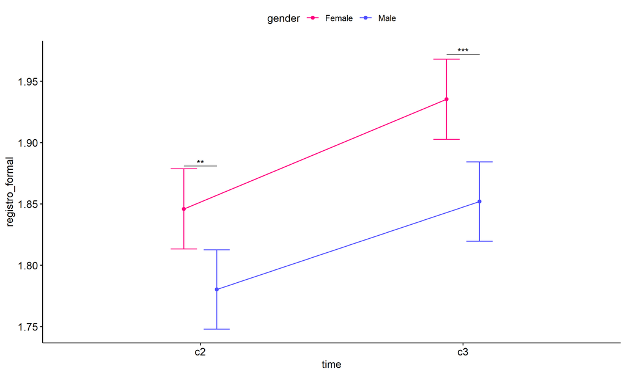

```r
pwc <- add_xy_position(pwc, x = "time", fun = "mean_se", dodge = 0.25)
pd <- position_dodge(width = 0.25)
ggline(emms, x = "time", y = "emmean", color = "gender",
       palette = c("#FF007F","#4D4DFF"),
       position = pd, ylab = "registro_formal") +
  geom_errorbar(aes(ymin = conf.low, ymax = conf.high, color = gender),
                position = pd, width = 0.2) +
  stat_pvalue_manual(pwc, hide.ns = T, tip.length = F, linetype = 1)
```

```r
(pwc <- ldat %>% group_by(gender) %>%
    emmeans_test(registro_formal ~ time, detailed = T, p.adjust.method = "bonferroni"))
```

```
## # A tibble: 2 × 15
##   gender term  .y.       group1 group2 null.value estimate     se    df conf.low
## * <fct>  <chr> <chr>     <chr>  <chr>       <dbl>    <dbl>  <dbl> <dbl>    <dbl>
## 1 Female time  registro… c2     c3              0  -0.0894 0.0236  7582   -0.136
## 2 Male   time  registro… c2     c3              0  -0.0717 0.0234  7582   -0.117
## # ℹ 5 more variables: conf.high <dbl>, statistic <dbl>, p <dbl>, p.adj <dbl>,
## #   p.adj.signif <chr>
```

| gender | term | .y. | group1 | group2 | null.value | estimate | se | df | conf.low | conf.high | statistic | p | p.adj | p.adj.signif |
| --- | --- | --- | --- | --- | --- | --- | --- | --- | --- | --- | --- | --- | --- | --- |
| Female | time | registro_formal | c2 | c3 | 0 | -0.089 | 0.024 | 7582 | -0.136 | -0.043 | -3.789 | 0.000 | 0.000 | *** |
| Male | time | registro_formal | c2 | c3 | 0 | -0.072 | 0.023 | 7582 | -0.117 | -0.026 | -3.070 | 0.002 | 0.002 | ** |

```r
(emms <- get_emmeans(pwc))
```

```
## # A tibble: 4 × 8
##   gender time  emmean     se    df conf.low conf.high method
##   <fct>  <fct>  <dbl>  <dbl> <dbl>    <dbl>     <dbl> <chr>
## 1 Female c2      1.85 0.0167  7582     1.81      1.88 Emmeans test
## 2 Female c3      1.94 0.0167  7582     1.90      1.97 Emmeans test
## 3 Male   c2      1.78 0.0165  7582     1.75      1.81 Emmeans test
## 4 Male   c3      1.85 0.0165  7582     1.82      1.88 Emmeans test
```

| gender | time | emmean | se | df | conf.low | conf.high | method |
| --- | --- | --- | --- | --- | --- | --- | --- |
| Female | c2 | 1.846 | 0.017 | 7582 | 1.813 | 1.879 | Emmeans test |
| Female | c3 | 1.935 | 0.017 | 7582 | 1.903 | 1.968 | Emmeans test |
| Male | c2 | 1.780 | 0.017 | 7582 | 1.748 | 1.813 | Emmeans test |
| Male | c3 | 1.852 | 0.017 | 7582 | 1.820 | 1.884 | Emmeans test |

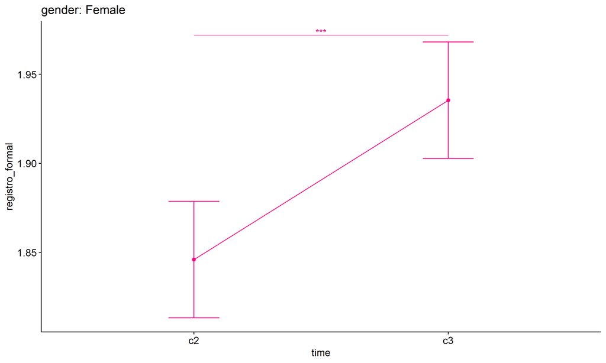

```r
emms.gg <- emms[which(emms$gender == "Female"),]
if (nrow(emms.gg) > 0)
  ggline(emms.gg, x = "time", y = "emmean", color = "#FF007F", ylab = "registro_formal") +
    geom_errorbar(aes(ymin = conf.low, ymax = conf.high),
                  width = 0.2, color = "#FF007F") +
    stat_pvalue_manual(
      add_xy_position(pwc[which(pwc$gender == "Female"),],
                      x = "time", fun = "mean_se"),
      hide.ns = T, color = "#FF007F", tip.length = F) +
    labs(title = "gender: Female")+
    theme(legend.text = element_blank())
```

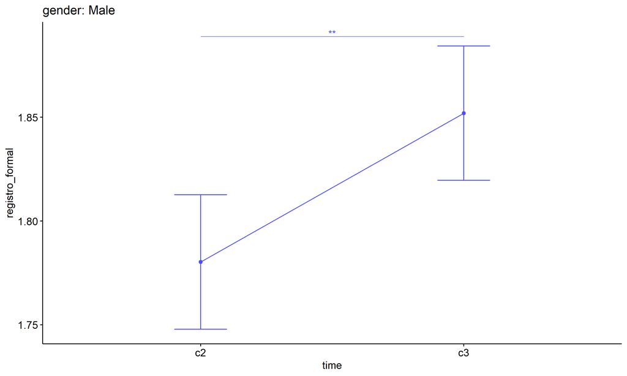

```r
emms.gg <- emms[which(emms$gender == "Male"),]
if (nrow(emms.gg) > 0)
  ggline(emms.gg, x = "time", y = "emmean", color = "#4D4DFF", ylab = "registro_formal") +
    geom_errorbar(aes(ymin = conf.low, ymax = conf.high),
                  width = 0.2, color = "#4D4DFF") +
    stat_pvalue_manual(
      add_xy_position(pwc[which(pwc$gender == "Male"),],
                      x = "time", fun = "mean_se"),
      hide.ns = T, color = "#4D4DFF", tip.length = F) +
    labs(title = "gender: Male")+
    theme(legend.text = element_blank())
```

## PairWise Computation after removing non.normal data

```r
if (length(non.ids) > 0)
  (pwc2 <- ldat2 %>% group_by(time) %>%
     emmeans_test(registro_formal ~ gender, detailed = T, p.adjust.method = "bonferroni"))
```

```r
if (length(non.ids) > 0)
  (emms2 <- get_emmeans(pwc2))
```

```r
if (length(non.ids) > 0) {
  pwc2 <- add_xy_position(pwc2, x = "time", fun = "mean_se", dodge = 0.25)
  pd2 <- position_dodge(width = 0.25)

  ggline(emms2, x = "time", y = "emmean", color = "gender",
         palette = c("#FF007F","#4D4DFF"),
         position = pd, ylab = "registro_formal") +
    geom_errorbar(aes(ymin = conf.low, ymax = conf.high, color = gender),
                position = pd, width = 0.2) +
    stat_pvalue_manual(pwc2, hide.ns = T, tip.length = F, linetype = 1)
}
```

```r
if (length(non.ids) > 0)
  (pwc2 <- ldat2 %>% group_by(gender) %>%
     emmeans_test(registro_formal ~ time, detailed = T, p.adjust.method = "bonferroni"))
```

```r
if (length(non.ids) > 0)
  (emms2 <- get_emmeans(pwc2))
```

```r
if (length(non.ids) > 0) {
  emms.gg <- emms2[which(emms2$gender == "Female"),]
  if (nrow(emms.gg) > 0)
    ggline(emms.gg, x = "time", y = "emmean", color = "#FF007F", ylab = "registro_formal") +
    geom_errorbar(aes(ymin = conf.low, ymax = conf.high),
                  width = 0.2, color = "#FF007F") +
    stat_pvalue_manual(
      add_xy_position(pwc[which(pwc$gender == "Female"),],
                      x = "time", fun = "mean_se"),
      hide.ns = T, color = "#FF007F", tip.length = F) +
    labs(title = "gender: Female") +
    theme(legend.text = element_blank())
}
```

```r
if (length(non.ids) > 0) {
  emms.gg <- emms2[which(emms2$gender == "Male"),]
  if (nrow(emms.gg) > 0)
    ggline(emms.gg, x = "time", y = "emmean", color = "#4D4DFF", ylab = "registro_formal") +
    geom_errorbar(aes(ymin = conf.low, ymax = conf.high),
                  width = 0.2, color = "#4D4DFF") +
    stat_pvalue_manual(
      add_xy_position(pwc[which(pwc$gender == "Male"),],
                      x = "time", fun = "mean_se"),
      hide.ns = T, color = "#4D4DFF", tip.length = F) +
    labs(title = "gender: Male") +
    theme(legend.text = element_blank())
}
```

# ANOVA: registro_formal ~ time*localizacao + Error(id/time)

## Data Preparation

```r
data <- edat[,c("aluno_id","localizacao","ciclo","registro_formal")]
data <- data[data$ciclo %in% c("Segundo Ciclo","Terceiro Ciclo"),]
data$ciclo <- factor(data$ciclo, c("Segundo Ciclo","Terceiro Ciclo"))
data <- unique(data)

wdat <- spread(data, ciclo, registro_formal)
wdat <- wdat[complete.cases(wdat),]
colnames(wdat) <- c("id","localizacao","c2","c3")

ldat <- gather(wdat, key = time, value = registro_formal, c2,c3) %>%
  convert_as_factor(id, time)
ldat <- remove_group_data(ldat, "registro_formal", c("time", "localizacao"), n.limit = 30)
ldat$localizacao <- factor(ldat$localizacao, sort(unique(ldat$localizacao)))
```

### Check assumptions: Identifying Outliers

```r
outliers <- identify_outliers(group_by(ldat, time, localizacao), registro_formal)
(outliers <- outliers[outliers$is.extreme == T,])
```

```
## # A tibble: 0 × 6
## # ℹ 6 variables: localizacao <fct>, time <fct>, id <fct>,
## #   registro_formal <dbl>, is.outlier <lgl>, is.extreme <lgl>
```

| localizacao | time | id | registro_formal | is.outlier | is.extreme |
| --- | --- | --- | --- | --- | --- |

### Check assumptions: Normality Test

```r
(normality.df <- normality.test.per.groups(ldat, "registro_formal", c("time", "localizacao")))
```

```
##               var        variable time localizacao    n  skewness   kurtosis
## 1 registro_formal registro_formal   c2       Rural  701 0.6969421  0.1560715
## 2 registro_formal registro_formal   c2      Urbana 3341 0.6320367  0.2134097
## 3 registro_formal registro_formal   c3       Rural  701 0.6306818  0.0209647
## 4 registro_formal registro_formal   c3      Urbana 3341 0.6054661 -0.1161836
##   symmetry statistic     method            p p.signif normality
## 1       NO  48.99880 D'Agostino 2.291112e-11     ****         -
## 2       NO 195.12966 D'Agostino 0.000000e+00     ****         -
## 3       NO  40.61319 D'Agostino 1.516903e-09     ****         -
## 4       NO 177.84464 D'Agostino 0.000000e+00     ****         -
```

| var | variable | time | localizacao | n | skewness | kurtosis | symmetry | statistic | method | p | p.signif | normality |
| --- | --- | --- | --- | --- | --- | --- | --- | --- | --- | --- | --- | --- |
| registro_formal | registro_formal | c2 | Rural | 701 | 0.697 | 0.156 | NO | 48.999 | D’Agostino | 0 | **** | - |
| registro_formal | registro_formal | c2 | Urbana | 3341 | 0.632 | 0.213 | NO | 195.130 | D’Agostino | 0 | **** | - |
| registro_formal | registro_formal | c3 | Rural | 701 | 0.631 | 0.021 | NO | 40.613 | D’Agostino | 0 | **** | - |
| registro_formal | registro_formal | c3 | Urbana | 3341 | 0.605 | -0.116 | NO | 177.845 | D’Agostino | 0 | **** | - |

```r
(non.ids <- unique(do.call(
  c, lapply(which(normality.df$normality == 'NO'), FUN = function(i) {
  idx = which(ldat$time == normality.df$time[i] &
                ldat$localizacao == normality.df$localizacao[i])
  getNonNormal(ldat$"registro_formal"[idx], ldat$id[idx])
}))))
```

```r
if (length(non.ids) > 0)
  ldat2 <- ldat[!ldat$id %in% non.ids,]
```

### Summary Statistics

```r
(sdat <- ldat %>% group_by(time, localizacao) %>%
   get_summary_stats(registro_formal, type = "mean_sd"))
```

```
## # A tibble: 4 × 6
##   localizacao time  variable            n  mean    sd
##   <fct>       <fct> <fct>           <dbl> <dbl> <dbl>
## 1 Rural       c2    registro_formal   701  1.84 0.72
## 2 Urbana      c2    registro_formal  3341  1.80 0.666
## 3 Rural       c3    registro_formal   701  1.89 0.759
## 4 Urbana      c3    registro_formal  3341  1.89 0.77
```

| localizacao | time | variable | n | mean | sd |
| --- | --- | --- | --- | --- | --- |
| Rural | c2 | registro_formal | 701 | 1.842 | 0.720 |
| Urbana | c2 | registro_formal | 3341 | 1.804 | 0.666 |
| Rural | c3 | registro_formal | 701 | 1.894 | 0.759 |
| Urbana | c3 | registro_formal | 3341 | 1.890 | 0.770 |

```r
if (length(non.ids) > 0)
  (sdat <- ldat2 %>% group_by(time, localizacao) %>%
      get_summary_stats(registro_formal, type = "mean_sd"))
```

| localizacao | time | variable | n | mean | sd |
| --- | --- | --- | --- | --- | --- |
| Rural | c2 | registro_formal | 701 | 1.842 | 0.720 |
| Urbana | c2 | registro_formal | 3341 | 1.804 | 0.666 |
| Rural | c3 | registro_formal | 701 | 1.894 | 0.759 |
| Urbana | c3 | registro_formal | 3341 | 1.890 | 0.770 |

## ANOVA Computation

```r
(res.aov <- anova_test(ldat, dv = registro_formal, wid = id, between = localizacao, within = time))
```

```
## ANOVA Table (type III tests)
##
##             Effect DFn  DFd      F        p p<.05      ges
## 1      localizacao   1 4040  0.879 0.349000       1.24e-04
## 2             time   1 4040 12.259 0.000468     * 1.00e-03
## 3 localizacao:time   1 4040  0.695 0.404000       7.39e-05
```

## ANOVA Computation after removing non.normal data

```r
if (length(non.ids) > 0)
  (res.aov2 <- anova_test(ldat2, dv = registro_formal, wid = id, between = localizacao , within = time))
```

## PairWise Computation

```r
(pwc <- ldat %>% group_by(time) %>%
   emmeans_test(registro_formal ~ localizacao, detailed = T, p.adjust.method = "bonferroni"))
```

```
## # A tibble: 2 × 15
##   time  term       .y.   group1 group2 null.value estimate     se    df conf.low
## * <fct> <chr>      <chr> <chr>  <chr>       <dbl>    <dbl>  <dbl> <dbl>    <dbl>
## 1 c2    localizac… regi… Rural  Urbana          0  0.0377  0.0301  8080  -0.0212
## 2 c3    localizac… regi… Rural  Urbana          0  0.00486 0.0301  8080  -0.0541
## # ℹ 5 more variables: conf.high <dbl>, statistic <dbl>, p <dbl>, p.adj <dbl>,
## #   p.adj.signif <chr>
```

| time | term | .y. | group1 | group2 | null.value | estimate | se | df | conf.low | conf.high | statistic | p | p.adj | p.adj.signif |
| --- | --- | --- | --- | --- | --- | --- | --- | --- | --- | --- | --- | --- | --- | --- |
| c2 | localizacao | registro_formal | Rural | Urbana | 0 | 0.038 | 0.03 | 8080 | -0.021 | 0.097 | 1.255 | 0.210 | 0.210 | ns |
| c3 | localizacao | registro_formal | Rural | Urbana | 0 | 0.005 | 0.03 | 8080 | -0.054 | 0.064 | 0.162 | 0.872 | 0.872 | ns |

```r
(emms <- get_emmeans(pwc))
```

```
## # A tibble: 4 × 8
##   time  localizacao emmean     se    df conf.low conf.high method
##   <fct> <fct>        <dbl>  <dbl> <dbl>    <dbl>     <dbl> <chr>
## 1 c2    Rural         1.84 0.0273  8080     1.79      1.90 Emmeans test
## 2 c2    Urbana        1.80 0.0125  8080     1.78      1.83 Emmeans test
## 3 c3    Rural         1.89 0.0273  8080     1.84      1.95 Emmeans test
## 4 c3    Urbana        1.89 0.0125  8080     1.87      1.91 Emmeans test
```

| time | localizacao | emmean | se | df | conf.low | conf.high | method |
| --- | --- | --- | --- | --- | --- | --- | --- |
| c2 | Rural | 1.842 | 0.027 | 8080 | 1.788 | 1.895 | Emmeans test |
| c2 | Urbana | 1.804 | 0.013 | 8080 | 1.780 | 1.829 | Emmeans test |
| c3 | Rural | 1.894 | 0.027 | 8080 | 1.841 | 1.948 | Emmeans test |
| c3 | Urbana | 1.890 | 0.013 | 8080 | 1.865 | 1.914 | Emmeans test |

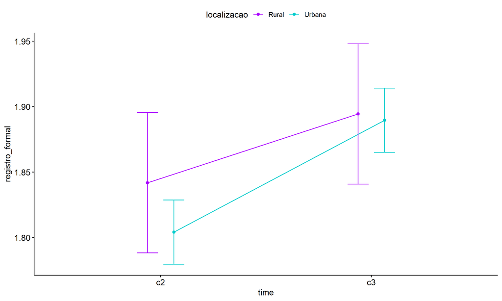

```r
pwc <- add_xy_position(pwc, x = "time", fun = "mean_se", dodge = 0.25)
pd <- position_dodge(width = 0.25)
ggline(emms, x = "time", y = "emmean", color = "localizacao",
       palette = c("#AA00FF","#00CCCC"),
       position = pd, ylab = "registro_formal") +
  geom_errorbar(aes(ymin = conf.low, ymax = conf.high, color = localizacao),
                position = pd, width = 0.2) +
  stat_pvalue_manual(pwc, hide.ns = T, tip.length = F, linetype = 1)
```

```r
(pwc <- ldat %>% group_by(localizacao) %>%
    emmeans_test(registro_formal ~ time, detailed = T, p.adjust.method = "bonferroni"))
```

```
## # A tibble: 2 × 15
##   localizacao term  .y.           group1 group2 null.value estimate     se    df
## * <fct>       <chr> <chr>         <chr>  <chr>       <dbl>    <dbl>  <dbl> <dbl>
## 1 Rural       time  registro_for… c2     c3              0  -0.0525 0.0386  8080
## 2 Urbana      time  registro_for… c2     c3              0  -0.0854 0.0177  8080
## # ℹ 6 more variables: conf.low <dbl>, conf.high <dbl>, statistic <dbl>,
## #   p <dbl>, p.adj <dbl>, p.adj.signif <chr>
```

| localizacao | term | .y. | group1 | group2 | null.value | estimate | se | df | conf.low | conf.high | statistic | p | p.adj | p.adj.signif |
| --- | --- | --- | --- | --- | --- | --- | --- | --- | --- | --- | --- | --- | --- | --- |
| Rural | time | registro_formal | c2 | c3 | 0 | -0.053 | 0.039 | 8080 | -0.128 | 0.023 | -1.360 | 0.174 | 0.174 | ns |
| Urbana | time | registro_formal | c2 | c3 | 0 | -0.085 | 0.018 | 8080 | -0.120 | -0.051 | -4.824 | 0.000 | 0.000 | **** |

```r
(emms <- get_emmeans(pwc))
```

```
## # A tibble: 4 × 8
##   localizacao time  emmean     se    df conf.low conf.high method
##   <fct>       <fct>  <dbl>  <dbl> <dbl>    <dbl>     <dbl> <chr>
## 1 Rural       c2      1.84 0.0273  8080     1.79      1.90 Emmeans test
## 2 Rural       c3      1.89 0.0273  8080     1.84      1.95 Emmeans test
## 3 Urbana      c2      1.80 0.0125  8080     1.78      1.83 Emmeans test
## 4 Urbana      c3      1.89 0.0125  8080     1.87      1.91 Emmeans test
```

| localizacao | time | emmean | se | df | conf.low | conf.high | method |
| --- | --- | --- | --- | --- | --- | --- | --- |
| Rural | c2 | 1.842 | 0.027 | 8080 | 1.788 | 1.895 | Emmeans test |
| Rural | c3 | 1.894 | 0.027 | 8080 | 1.841 | 1.948 | Emmeans test |
| Urbana | c2 | 1.804 | 0.013 | 8080 | 1.780 | 1.829 | Emmeans test |
| Urbana | c3 | 1.890 | 0.013 | 8080 | 1.865 | 1.914 | Emmeans test |

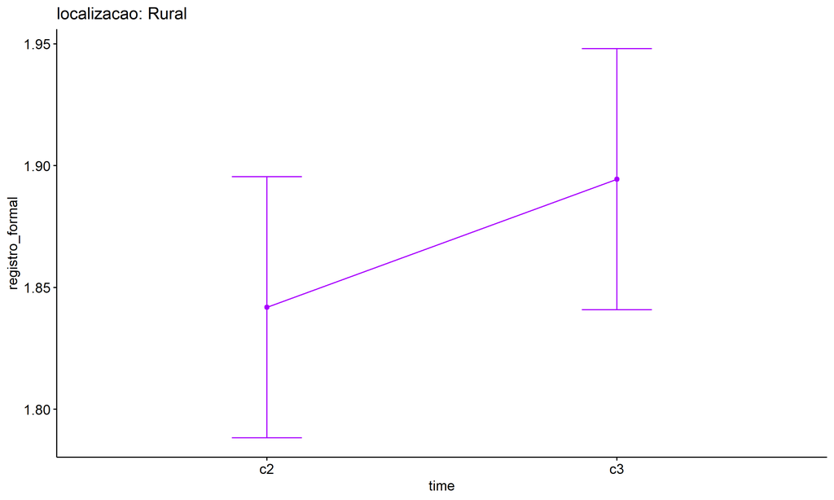

```r
emms.gg <- emms[which(emms$localizacao == "Rural"),]
if (nrow(emms.gg) > 0)
  ggline(emms.gg, x = "time", y = "emmean", color = "#AA00FF", ylab = "registro_formal") +
    geom_errorbar(aes(ymin = conf.low, ymax = conf.high),
                  width = 0.2, color = "#AA00FF") +
    stat_pvalue_manual(
      add_xy_position(pwc[which(pwc$localizacao == "Rural"),],
                      x = "time", fun = "mean_se"),
      hide.ns = T, color = "#AA00FF", tip.length = F) +
    labs(title = "localizacao: Rural")+
    theme(legend.text = element_blank())
```

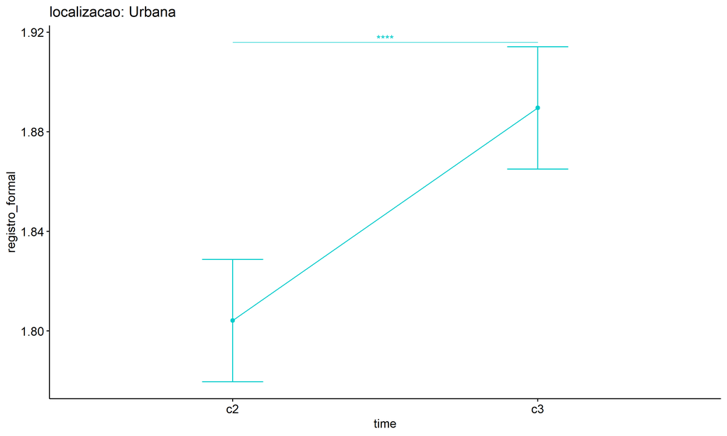

```r
emms.gg <- emms[which(emms$localizacao == "Urbana"),]
if (nrow(emms.gg) > 0)
  ggline(emms.gg, x = "time", y = "emmean", color = "#00CCCC", ylab = "registro_formal") +
    geom_errorbar(aes(ymin = conf.low, ymax = conf.high),
                  width = 0.2, color = "#00CCCC") +
    stat_pvalue_manual(
      add_xy_position(pwc[which(pwc$localizacao == "Urbana"),],
                      x = "time", fun = "mean_se"),
      hide.ns = T, color = "#00CCCC", tip.length = F) +
    labs(title = "localizacao: Urbana")+
    theme(legend.text = element_blank())
```

## PairWise Computation after removing non.normal data

```r
if (length(non.ids) > 0)
  (pwc2 <- ldat2 %>% group_by(time) %>%
     emmeans_test(registro_formal ~ localizacao, detailed = T, p.adjust.method = "bonferroni"))
```

```r
if (length(non.ids) > 0)
  (emms2 <- get_emmeans(pwc2))
```

```r
if (length(non.ids) > 0) {
  pwc2 <- add_xy_position(pwc2, x = "time", fun = "mean_se", dodge = 0.25)
  pd2 <- position_dodge(width = 0.25)

  ggline(emms2, x = "time", y = "emmean", color = "localizacao",
         palette = c("#AA00FF","#00CCCC"),
         position = pd, ylab = "registro_formal") +
    geom_errorbar(aes(ymin = conf.low, ymax = conf.high, color = localizacao),
                position = pd, width = 0.2) +
    stat_pvalue_manual(pwc2, hide.ns = T, tip.length = F, linetype = 1)
}
```

```r
if (length(non.ids) > 0)
  (pwc2 <- ldat2 %>% group_by(localizacao) %>%
     emmeans_test(registro_formal ~ time, detailed = T, p.adjust.method = "bonferroni"))
```

```r
if (length(non.ids) > 0)
  (emms2 <- get_emmeans(pwc2))
```

```r
if (length(non.ids) > 0) {
  emms.gg <- emms2[which(emms2$localizacao == "Rural"),]
  if (nrow(emms.gg) > 0)
    ggline(emms.gg, x = "time", y = "emmean", color = "#AA00FF", ylab = "registro_formal") +
    geom_errorbar(aes(ymin = conf.low, ymax = conf.high),
                  width = 0.2, color = "#AA00FF") +
    stat_pvalue_manual(
      add_xy_position(pwc[which(pwc$localizacao == "Rural"),],
                      x = "time", fun = "mean_se"),
      hide.ns = T, color = "#AA00FF", tip.length = F) +
    labs(title = "localizacao: Rural") +
    theme(legend.text = element_blank())
}
```

```r
if (length(non.ids) > 0) {
  emms.gg <- emms2[which(emms2$localizacao == "Urbana"),]
  if (nrow(emms.gg) > 0)
    ggline(emms.gg, x = "time", y = "emmean", color = "#00CCCC", ylab = "registro_formal") +
    geom_errorbar(aes(ymin = conf.low, ymax = conf.high),
                  width = 0.2, color = "#00CCCC") +
    stat_pvalue_manual(
      add_xy_position(pwc[which(pwc$localizacao == "Urbana"),],
                      x = "time", fun = "mean_se"),
      hide.ns = T, color = "#00CCCC", tip.length = F) +
    labs(title = "localizacao: Urbana") +
    theme(legend.text = element_blank())
}
```

# ANOVA: registro_formal ~ time*regiao + Error(id/time)

## Data Preparation

```r
data <- edat[,c("aluno_id","regiao","ciclo","registro_formal")]
data <- data[data$ciclo %in% c("Segundo Ciclo","Terceiro Ciclo"),]
data$ciclo <- factor(data$ciclo, c("Segundo Ciclo","Terceiro Ciclo"))
data <- unique(data)

wdat <- spread(data, ciclo, registro_formal)
wdat <- wdat[complete.cases(wdat),]
colnames(wdat) <- c("id","regiao","c2","c3")

ldat <- gather(wdat, key = time, value = registro_formal, c2,c3) %>%
  convert_as_factor(id, time)
ldat <- remove_group_data(ldat, "registro_formal", c("time", "regiao"), n.limit = 30)
ldat$regiao <- factor(ldat$regiao, sort(unique(ldat$regiao)))
```

### Check assumptions: Identifying Outliers

```r
outliers <- identify_outliers(group_by(ldat, time, regiao), registro_formal)
(outliers <- outliers[outliers$is.extreme == T,])
```

```
## # A tibble: 9 × 6
##   regiao       time  id                   registro_formal is.outlier is.extreme
##   <fct>        <fct> <fct>                          <dbl> <lgl>      <lgl>
## 1 Centro-Oeste c2    r3PujYNAinSR5cUFlfvp               4 TRUE       TRUE
## 2 Centro-Oeste c2    Y2PeRXdBAGLBFeH7y8gi               4 TRUE       TRUE
## 3 Norte        c2    6VpAfRDnPV0NobbSZz6t               4 TRUE       TRUE
## 4 Norte        c2    MMxwyxd4awvO9GeCPT31               4 TRUE       TRUE
## 5 Norte        c2    nlFUxxicgyBUxv5P70b4               4 TRUE       TRUE
## 6 Norte        c2    pE3uZjAhHMt901ywnKaz               4 TRUE       TRUE
## 7 Norte        c2    QbHHWjffOuNc6dkoLs82               4 TRUE       TRUE
## 8 Norte        c2    qfeMJi8RWcj2xT6hr2Ju               4 TRUE       TRUE
## 9 Norte        c2    rMFW9JbLltZ7FvUOlDQd               4 TRUE       TRUE
```

| regiao | time | id | registro_formal | is.outlier | is.extreme |
| --- | --- | --- | --- | --- | --- |
| Centro-Oeste | c2 | r3PujYNAinSR5cUFlfvp | 4 | TRUE | TRUE |
| Centro-Oeste | c2 | Y2PeRXdBAGLBFeH7y8gi | 4 | TRUE | TRUE |
| Norte | c2 | 6VpAfRDnPV0NobbSZz6t | 4 | TRUE | TRUE |
| Norte | c2 | MMxwyxd4awvO9GeCPT31 | 4 | TRUE | TRUE |
| Norte | c2 | nlFUxxicgyBUxv5P70b4 | 4 | TRUE | TRUE |
| Norte | c2 | pE3uZjAhHMt901ywnKaz | 4 | TRUE | TRUE |
| Norte | c2 | QbHHWjffOuNc6dkoLs82 | 4 | TRUE | TRUE |
| Norte | c2 | qfeMJi8RWcj2xT6hr2Ju | 4 | TRUE | TRUE |
| Norte | c2 | rMFW9JbLltZ7FvUOlDQd | 4 | TRUE | TRUE |

### Check assumptions: Normality Test

```r
(normality.df <- normality.test.per.groups(ldat, "registro_formal", c("time", "regiao")))
```

```
##                var        variable time       regiao    n   skewness
## 1  registro_formal registro_formal   c2 Centro-Oeste  198 0.48263254
## 2  registro_formal registro_formal   c2     Nordeste 1464 0.56066582
## 3  registro_formal registro_formal   c2        Norte  435 0.49065231
## 4  registro_formal registro_formal   c2      Sudeste 1473 0.82132124
## 5  registro_formal registro_formal   c2          Sul  472 0.53742418
## 6  registro_formal registro_formal   c3 Centro-Oeste  198 0.08626711
## 7  registro_formal registro_formal   c3     Nordeste 1464 0.70719939
## 8  registro_formal registro_formal   c3        Norte  435 0.65425655
## 9  registro_formal registro_formal   c3      Sudeste 1473 0.62429154
## 10 registro_formal registro_formal   c3          Sul  472 0.34250126
##       kurtosis symmetry  statistic     method            p p.signif normality
## 1  -0.23686677      YES   7.800998 D'Agostino 2.023181e-02       ns        QQ
## 2  -0.04702798       NO  67.972388 D'Agostino 1.776357e-15     ****         -
## 3   0.11600830      YES  16.881887 D'Agostino 2.158464e-04       **         -
## 4   0.79331106       NO 152.181777 D'Agostino 0.000000e+00     ****         -
## 5   0.02984952       NO  21.002206 D'Agostino 2.750610e-05      ***         -
## 6  -0.51130036      YES   2.980326 D'Agostino 2.253360e-01       ns        QQ
## 7   0.08295281       NO 101.858305 D'Agostino 0.000000e+00     ****         -
## 8   0.08185968       NO  27.570408 D'Agostino 1.030771e-06     ****         -
## 9  -0.21295718       NO  85.490929 D'Agostino 0.000000e+00     ****         -
## 10 -0.24632964      YES  10.150675 D'Agostino 6.248978e-03        *         -
```

| var | variable | time | regiao | n | skewness | kurtosis | symmetry | statistic | method | p | p.signif | normality |
| --- | --- | --- | --- | --- | --- | --- | --- | --- | --- | --- | --- | --- |
| registro_formal | registro_formal | c2 | Centro-Oeste | 198 | 0.483 | -0.237 | YES | 7.801 | D’Agostino | 0.020 | ns | QQ |
| registro_formal | registro_formal | c2 | Nordeste | 1464 | 0.561 | -0.047 | NO | 67.972 | D’Agostino | 0.000 | **** | - |
| registro_formal | registro_formal | c2 | Norte | 435 | 0.491 | 0.116 | YES | 16.882 | D’Agostino | 0.000 | ** | - |
| registro_formal | registro_formal | c2 | Sudeste | 1473 | 0.821 | 0.793 | NO | 152.182 | D’Agostino | 0.000 | **** | - |
| registro_formal | registro_formal | c2 | Sul | 472 | 0.537 | 0.030 | NO | 21.002 | D’Agostino | 0.000 | *** | - |
| registro_formal | registro_formal | c3 | Centro-Oeste | 198 | 0.086 | -0.511 | YES | 2.980 | D’Agostino | 0.225 | ns | QQ |
| registro_formal | registro_formal | c3 | Nordeste | 1464 | 0.707 | 0.083 | NO | 101.858 | D’Agostino | 0.000 | **** | - |
| registro_formal | registro_formal | c3 | Norte | 435 | 0.654 | 0.082 | NO | 27.570 | D’Agostino | 0.000 | **** | - |
| registro_formal | registro_formal | c3 | Sudeste | 1473 | 0.624 | -0.213 | NO | 85.491 | D’Agostino | 0.000 | **** | - |
| registro_formal | registro_formal | c3 | Sul | 472 | 0.343 | -0.246 | YES | 10.151 | D’Agostino | 0.006 | * | - |

```r
(non.ids <- unique(do.call(
  c, lapply(which(normality.df$normality == 'NO'), FUN = function(i) {
  idx = which(ldat$time == normality.df$time[i] &
                ldat$regiao == normality.df$regiao[i])
  getNonNormal(ldat$"registro_formal"[idx], ldat$id[idx])
}))))
```

```r
if (length(non.ids) > 0)
  ldat2 <- ldat[!ldat$id %in% non.ids,]
```

### Summary Statistics

```r
(sdat <- ldat %>% group_by(time, regiao) %>%
   get_summary_stats(registro_formal, type = "mean_sd"))
```

```
## # A tibble: 10 × 6
##    regiao       time  variable            n  mean    sd
##    <fct>        <fct> <fct>           <dbl> <dbl> <dbl>
##  1 Centro-Oeste c2    registro_formal   198  1.90 0.675
##  2 Nordeste     c2    registro_formal  1464  1.85 0.7
##  3 Norte        c2    registro_formal   435  1.91 0.688
##  4 Sudeste      c2    registro_formal  1473  1.7  0.616
##  5 Sul          c2    registro_formal   472  1.91 0.722
##  6 Centro-Oeste c3    registro_formal   198  1.98 0.609
##  7 Nordeste     c3    registro_formal  1464  1.80 0.742
##  8 Norte        c3    registro_formal   435  1.88 0.757
##  9 Sudeste      c3    registro_formal  1473  1.93 0.81
## 10 Sul          c3    registro_formal   472  2.04 0.747
```

| regiao | time | variable | n | mean | sd |
| --- | --- | --- | --- | --- | --- |
| Centro-Oeste | c2 | registro_formal | 198 | 1.905 | 0.675 |
| Nordeste | c2 | registro_formal | 1464 | 1.849 | 0.700 |
| Norte | c2 | registro_formal | 435 | 1.907 | 0.688 |
| Sudeste | c2 | registro_formal | 1473 | 1.700 | 0.616 |
| Sul | c2 | registro_formal | 472 | 1.911 | 0.722 |
| Centro-Oeste | c3 | registro_formal | 198 | 1.977 | 0.609 |
| Nordeste | c3 | registro_formal | 1464 | 1.796 | 0.742 |
| Norte | c3 | registro_formal | 435 | 1.877 | 0.757 |
| Sudeste | c3 | registro_formal | 1473 | 1.928 | 0.810 |
| Sul | c3 | registro_formal | 472 | 2.042 | 0.747 |

```r
if (length(non.ids) > 0)
  (sdat <- ldat2 %>% group_by(time, regiao) %>%
      get_summary_stats(registro_formal, type = "mean_sd"))
```

| regiao | time | variable | n | mean | sd |
| --- | --- | --- | --- | --- | --- |
| Centro-Oeste | c2 | registro_formal | 198 | 1.905 | 0.675 |
| Nordeste | c2 | registro_formal | 1464 | 1.849 | 0.700 |
| Norte | c2 | registro_formal | 435 | 1.907 | 0.688 |
| Sudeste | c2 | registro_formal | 1473 | 1.700 | 0.616 |
| Sul | c2 | registro_formal | 472 | 1.911 | 0.722 |
| Centro-Oeste | c3 | registro_formal | 198 | 1.977 | 0.609 |
| Nordeste | c3 | registro_formal | 1464 | 1.796 | 0.742 |
| Norte | c3 | registro_formal | 435 | 1.877 | 0.757 |
| Sudeste | c3 | registro_formal | 1473 | 1.928 | 0.810 |
| Sul | c3 | registro_formal | 472 | 2.042 | 0.747 |

## ANOVA Computation

```r
(res.aov <- anova_test(ldat, dv = registro_formal, wid = id, between = regiao, within = time))
```

```
## ANOVA Table (type III tests)
##
##        Effect DFn  DFd      F        p p<.05   ges
## 1      regiao   4 4037 10.988 7.32e-09     * 0.006
## 2        time   1 4037 12.748 3.60e-04     * 0.001
## 3 regiao:time   4 4037 18.252 7.15e-15     * 0.008
```

## ANOVA Computation after removing non.normal data

```r
if (length(non.ids) > 0)
  (res.aov2 <- anova_test(ldat2, dv = registro_formal, wid = id, between = regiao , within = time))
```

## PairWise Computation

```r
(pwc <- ldat %>% group_by(time) %>%
   emmeans_test(registro_formal ~ regiao, detailed = T, p.adjust.method = "bonferroni"))
```

| time | term | .y. | group1 | group2 | null.value | estimate | se | df | conf.low | conf.high | statistic | p | p.adj | p.adj.signif |
| --- | --- | --- | --- | --- | --- | --- | --- | --- | --- | --- | --- | --- | --- | --- |
| c2 | regiao | registro_formal | Centro | Oeste | 0 | 0.057 | 0.054 | 8074 | -0.050 | 0.163 | 1.042 | 0.297 | 1.000 | ns |
| c2 | regiao | registro_formal | Centro | Oeste | 0 | -0.001 | 0.062 | 8074 | -0.122 | 0.120 | -0.020 | 0.984 | 1.000 | ns |
| c2 | regiao | registro_formal | Centro | Oeste | 0 | 0.205 | 0.054 | 8074 | 0.099 | 0.312 | 3.772 | 0.000 | 0.002 | ** |
| c2 | regiao | registro_formal | Centro | Oeste | 0 | -0.005 | 0.061 | 8074 | -0.125 | 0.114 | -0.088 | 0.930 | 1.000 | ns |
| c2 | regiao | registro_formal | Nordeste | Norte | 0 | -0.058 | 0.039 | 8074 | -0.135 | 0.019 | -1.476 | 0.140 | 1.000 | ns |
| c2 | regiao | registro_formal | Nordeste | Sudeste | 0 | 0.149 | 0.027 | 8074 | 0.097 | 0.201 | 5.599 | 0.000 | 0.000 | **** |
| c2 | regiao | registro_formal | Nordeste | Sul | 0 | -0.062 | 0.038 | 8074 | -0.137 | 0.013 | -1.631 | 0.103 | 1.000 | ns |
| c2 | regiao | registro_formal | Norte | Sudeste | 0 | 0.206 | 0.039 | 8074 | 0.130 | 0.283 | 5.263 | 0.000 | 0.000 | **** |
| c2 | regiao | registro_formal | Norte | Sul | 0 | -0.004 | 0.048 | 8074 | -0.098 | 0.090 | -0.087 | 0.931 | 1.000 | ns |
| c2 | regiao | registro_formal | Sudeste | Sul | 0 | -0.211 | 0.038 | 8074 | -0.285 | -0.136 | -5.539 | 0.000 | 0.000 | **** |
| c3 | regiao | registro_formal | Centro | Oeste | 0 | 0.181 | 0.054 | 8074 | 0.075 | 0.288 | 3.333 | 0.001 | 0.009 | ** |
| c3 | regiao | registro_formal | Centro | Oeste | 0 | 0.100 | 0.062 | 8074 | -0.021 | 0.221 | 1.627 | 0.104 | 1.000 | ns |
| c3 | regiao | registro_formal | Centro | Oeste | 0 | 0.049 | 0.054 | 8074 | -0.057 | 0.156 | 0.905 | 0.366 | 1.000 | ns |
| c3 | regiao | registro_formal | Centro | Oeste | 0 | -0.065 | 0.061 | 8074 | -0.184 | 0.054 | -1.070 | 0.285 | 1.000 | ns |
| c3 | regiao | registro_formal | Nordeste | Norte | 0 | -0.081 | 0.039 | 8074 | -0.158 | -0.004 | -2.068 | 0.039 | 0.386 | ns |
| c3 | regiao | registro_formal | Nordeste | Sudeste | 0 | -0.132 | 0.027 | 8074 | -0.184 | -0.080 | -4.984 | 0.000 | 0.000 | **** |
| c3 | regiao | registro_formal | Nordeste | Sul | 0 | -0.247 | 0.038 | 8074 | -0.321 | -0.172 | -6.480 | 0.000 | 0.000 | **** |
| c3 | regiao | registro_formal | Norte | Sudeste | 0 | -0.051 | 0.039 | 8074 | -0.128 | 0.026 | -1.301 | 0.193 | 1.000 | ns |
| c3 | regiao | registro_formal | Norte | Sul | 0 | -0.165 | 0.048 | 8074 | -0.259 | -0.072 | -3.461 | 0.001 | 0.005 | ** |
| c3 | regiao | registro_formal | Sudeste | Sul | 0 | -0.114 | 0.038 | 8074 | -0.189 | -0.040 | -3.007 | 0.003 | 0.026 | * |

```r
(emms <- get_emmeans(pwc))
```

```
## # A tibble: 10 × 8
##    time  regiao       emmean     se    df conf.low conf.high method
##    <fct> <fct>         <dbl>  <dbl> <dbl>    <dbl>     <dbl> <chr>
##  1 c2    Centro-Oeste   1.91 0.0511  8074     1.81      2.01 Emmeans test
##  2 c2    Nordeste       1.85 0.0188  8074     1.81      1.89 Emmeans test
##  3 c2    Norte          1.91 0.0345  8074     1.84      1.97 Emmeans test
##  4 c2    Sudeste        1.70 0.0187  8074     1.66      1.74 Emmeans test
##  5 c2    Sul            1.91 0.0331  8074     1.85      1.98 Emmeans test
##  6 c3    Centro-Oeste   1.98 0.0511  8074     1.88      2.08 Emmeans test
##  7 c3    Nordeste       1.80 0.0188  8074     1.76      1.83 Emmeans test
##  8 c3    Norte          1.88 0.0345  8074     1.81      1.94 Emmeans test
##  9 c3    Sudeste        1.93 0.0187  8074     1.89      1.96 Emmeans test
## 10 c3    Sul            2.04 0.0331  8074     1.98      2.11 Emmeans test
```

| time | regiao | emmean | se | df | conf.low | conf.high | method |
| --- | --- | --- | --- | --- | --- | --- | --- |
| c2 | Centro-Oeste | 1.905 | 0.051 | 8074 | 1.805 | 2.005 | Emmeans test |
| c2 | Nordeste | 1.849 | 0.019 | 8074 | 1.812 | 1.885 | Emmeans test |
| c2 | Norte | 1.907 | 0.034 | 8074 | 1.839 | 1.974 | Emmeans test |
| c2 | Sudeste | 1.700 | 0.019 | 8074 | 1.663 | 1.737 | Emmeans test |
| c2 | Sul | 1.911 | 0.033 | 8074 | 1.846 | 1.976 | Emmeans test |
| c3 | Centro-Oeste | 1.977 | 0.051 | 8074 | 1.877 | 2.077 | Emmeans test |
| c3 | Nordeste | 1.796 | 0.019 | 8074 | 1.759 | 1.833 | Emmeans test |
| c3 | Norte | 1.877 | 0.034 | 8074 | 1.809 | 1.945 | Emmeans test |
| c3 | Sudeste | 1.928 | 0.019 | 8074 | 1.891 | 1.965 | Emmeans test |
| c3 | Sul | 2.042 | 0.033 | 8074 | 1.978 | 2.107 | Emmeans test |

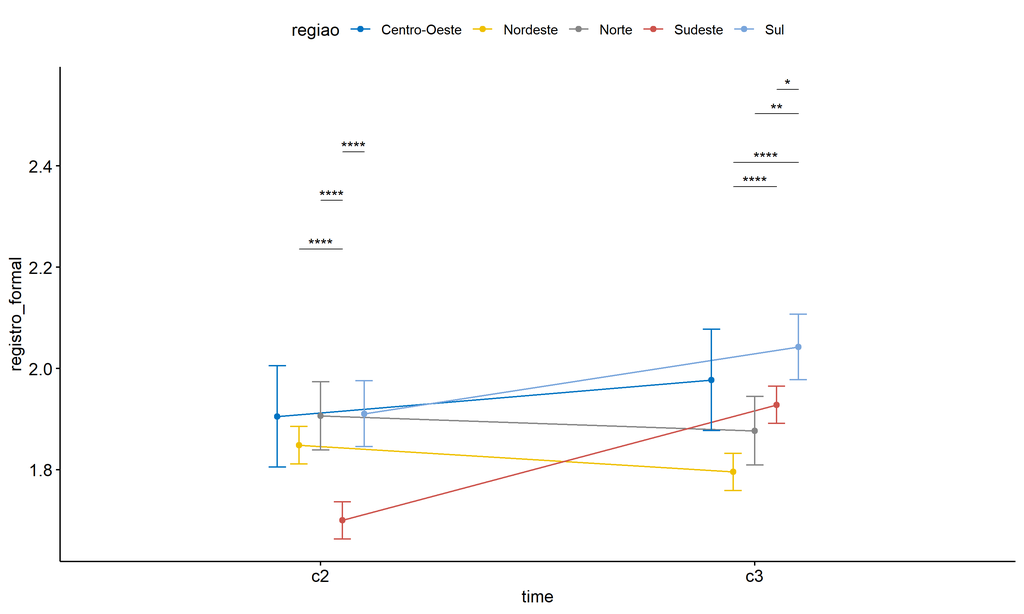

```r
pwc <- add_xy_position(pwc, x = "time", fun = "mean_se", dodge = 0.25)
pd <- position_dodge(width = 0.25)
ggline(emms, x = "time", y = "emmean", color = "regiao",
       palette = c("#0073C2FF","#EFC000FF","#868686FF","#CD534CFF","#7AA6DCFF"),
       position = pd, ylab = "registro_formal") +
  geom_errorbar(aes(ymin = conf.low, ymax = conf.high, color = regiao),
                position = pd, width = 0.2) +
  stat_pvalue_manual(pwc, hide.ns = T, tip.length = F, linetype = 1)
```

```r
(pwc <- ldat %>% group_by(regiao) %>%
    emmeans_test(registro_formal ~ time, detailed = T, p.adjust.method = "bonferroni"))
```

```
## # A tibble: 5 × 15
##   regiao     term  .y.   group1 group2 null.value estimate     se    df conf.low
## * <fct>      <chr> <chr> <chr>  <chr>       <dbl>    <dbl>  <dbl> <dbl>    <dbl>
## 1 Centro-Oe… time  regi… c2     c3              0  -0.0720 0.0722  8074 -2.14e-1
## 2 Nordeste   time  regi… c2     c3              0   0.0528 0.0266  8074  6.82e-4
## 3 Norte      time  regi… c2     c3              0   0.0295 0.0487  8074 -6.60e-2
## 4 Sudeste    time  regi… c2     c3              0  -0.228  0.0265  8074 -2.80e-1
## 5 Sul        time  regi… c2     c3              0  -0.132  0.0468  8074 -2.23e-1
## # ℹ 5 more variables: conf.high <dbl>, statistic <dbl>, p <dbl>, p.adj <dbl>,
## #   p.adj.signif <chr>
```

| regiao | term | .y. | group1 | group2 | null.value | estimate | se | df | conf.low | conf.high | statistic | p | p.adj | p.adj.signif |
| --- | --- | --- | --- | --- | --- | --- | --- | --- | --- | --- | --- | --- | --- | --- |
| Centro-Oeste | time | registro_formal | c2 | c3 | 0 | -0.072 | 0.072 | 8074 | -0.214 | 0.070 | -0.996 | 0.319 | 0.319 | ns |
| Nordeste | time | registro_formal | c2 | c3 | 0 | 0.053 | 0.027 | 8074 | 0.001 | 0.105 | 1.986 | 0.047 | 0.047 | * |
| Norte | time | registro_formal | c2 | c3 | 0 | 0.030 | 0.049 | 8074 | -0.066 | 0.125 | 0.605 | 0.545 | 0.545 | ns |
| Sudeste | time | registro_formal | c2 | c3 | 0 | -0.228 | 0.026 | 8074 | -0.280 | -0.176 | -8.607 | 0.000 | 0.000 | **** |
| Sul | time | registro_formal | c2 | c3 | 0 | -0.132 | 0.047 | 8074 | -0.223 | -0.040 | -2.815 | 0.005 | 0.005 | ** |

```r
(emms <- get_emmeans(pwc))
```

```
## # A tibble: 10 × 8
##    regiao       time  emmean     se    df conf.low conf.high method
##    <fct>        <fct>  <dbl>  <dbl> <dbl>    <dbl>     <dbl> <chr>
##  1 Centro-Oeste c2      1.91 0.0511  8074     1.81      2.01 Emmeans test
##  2 Centro-Oeste c3      1.98 0.0511  8074     1.88      2.08 Emmeans test
##  3 Nordeste     c2      1.85 0.0188  8074     1.81      1.89 Emmeans test
##  4 Nordeste     c3      1.80 0.0188  8074     1.76      1.83 Emmeans test
##  5 Norte        c2      1.91 0.0345  8074     1.84      1.97 Emmeans test
##  6 Norte        c3      1.88 0.0345  8074     1.81      1.94 Emmeans test
##  7 Sudeste      c2      1.70 0.0187  8074     1.66      1.74 Emmeans test
##  8 Sudeste      c3      1.93 0.0187  8074     1.89      1.96 Emmeans test
##  9 Sul          c2      1.91 0.0331  8074     1.85      1.98 Emmeans test
## 10 Sul          c3      2.04 0.0331  8074     1.98      2.11 Emmeans test
```

| regiao | time | emmean | se | df | conf.low | conf.high | method |
| --- | --- | --- | --- | --- | --- | --- | --- |
| Centro-Oeste | c2 | 1.905 | 0.051 | 8074 | 1.805 | 2.005 | Emmeans test |
| Centro-Oeste | c3 | 1.977 | 0.051 | 8074 | 1.877 | 2.077 | Emmeans test |
| Nordeste | c2 | 1.849 | 0.019 | 8074 | 1.812 | 1.885 | Emmeans test |
| Nordeste | c3 | 1.796 | 0.019 | 8074 | 1.759 | 1.833 | Emmeans test |
| Norte | c2 | 1.907 | 0.034 | 8074 | 1.839 | 1.974 | Emmeans test |
| Norte | c3 | 1.877 | 0.034 | 8074 | 1.809 | 1.945 | Emmeans test |
| Sudeste | c2 | 1.700 | 0.019 | 8074 | 1.663 | 1.737 | Emmeans test |
| Sudeste | c3 | 1.928 | 0.019 | 8074 | 1.891 | 1.965 | Emmeans test |
| Sul | c2 | 1.911 | 0.033 | 8074 | 1.846 | 1.976 | Emmeans test |
| Sul | c3 | 2.042 | 0.033 | 8074 | 1.978 | 2.107 | Emmeans test |

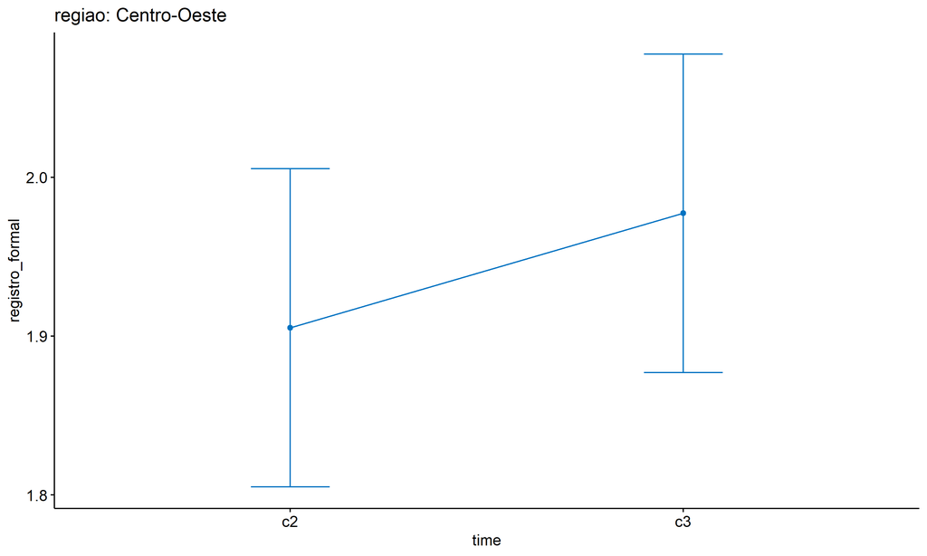

```r
emms.gg <- emms[which(emms$regiao == "Centro-Oeste"),]
if (nrow(emms.gg) > 0)
  ggline(emms.gg, x = "time", y = "emmean", color = "#0073C2FF", ylab = "registro_formal") +
    geom_errorbar(aes(ymin = conf.low, ymax = conf.high),
                  width = 0.2, color = "#0073C2FF") +
    stat_pvalue_manual(
      add_xy_position(pwc[which(pwc$regiao == "Centro-Oeste"),],
                      x = "time", fun = "mean_se"),
      hide.ns = T, color = "#0073C2FF", tip.length = F) +
    labs(title = "regiao: Centro-Oeste")+
    theme(legend.text = element_blank())
```

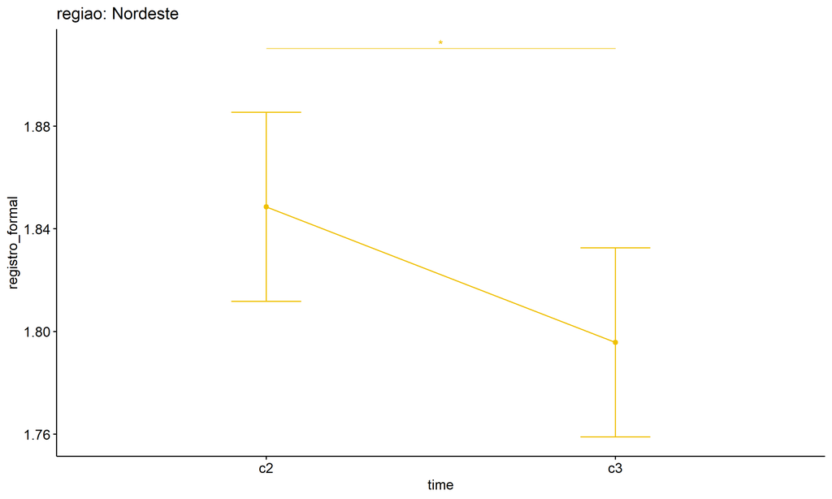

```r
emms.gg <- emms[which(emms$regiao == "Nordeste"),]
if (nrow(emms.gg) > 0)
  ggline(emms.gg, x = "time", y = "emmean", color = "#EFC000FF", ylab = "registro_formal") +
    geom_errorbar(aes(ymin = conf.low, ymax = conf.high),
                  width = 0.2, color = "#EFC000FF") +
    stat_pvalue_manual(
      add_xy_position(pwc[which(pwc$regiao == "Nordeste"),],
                      x = "time", fun = "mean_se"),
      hide.ns = T, color = "#EFC000FF", tip.length = F) +
    labs(title = "regiao: Nordeste")+
    theme(legend.text = element_blank())
```

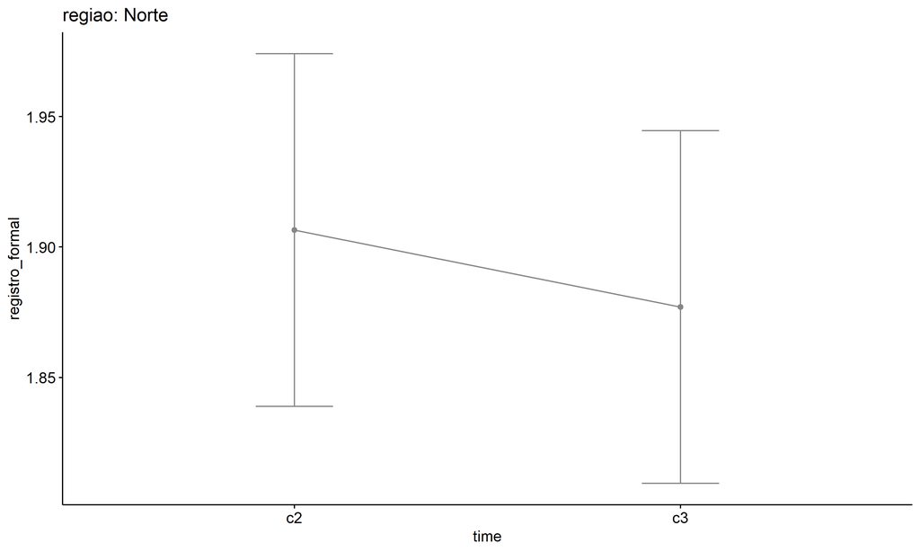

```r
emms.gg <- emms[which(emms$regiao == "Norte"),]
if (nrow(emms.gg) > 0)
  ggline(emms.gg, x = "time", y = "emmean", color = "#868686FF", ylab = "registro_formal") +
    geom_errorbar(aes(ymin = conf.low, ymax = conf.high),
                  width = 0.2, color = "#868686FF") +
    stat_pvalue_manual(
      add_xy_position(pwc[which(pwc$regiao == "Norte"),],
                      x = "time", fun = "mean_se"),
      hide.ns = T, color = "#868686FF", tip.length = F) +
    labs(title = "regiao: Norte")+
    theme(legend.text = element_blank())
```

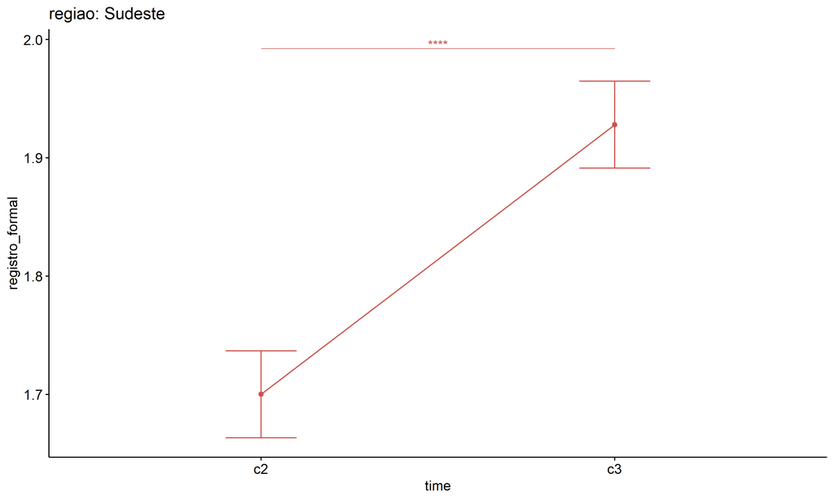

```r
emms.gg <- emms[which(emms$regiao == "Sudeste"),]
if (nrow(emms.gg) > 0)
  ggline(emms.gg, x = "time", y = "emmean", color = "#CD534CFF", ylab = "registro_formal") +
    geom_errorbar(aes(ymin = conf.low, ymax = conf.high),
                  width = 0.2, color = "#CD534CFF") +
    stat_pvalue_manual(
      add_xy_position(pwc[which(pwc$regiao == "Sudeste"),],
                      x = "time", fun = "mean_se"),
      hide.ns = T, color = "#CD534CFF", tip.length = F) +
    labs(title = "regiao: Sudeste")+
    theme(legend.text = element_blank())
```

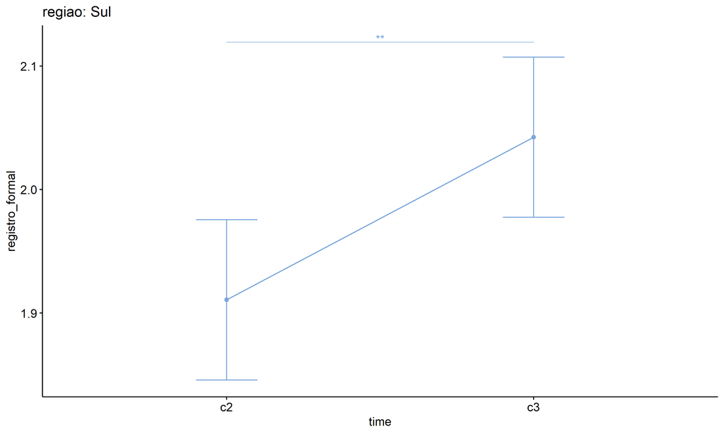

```r
emms.gg <- emms[which(emms$regiao == "Sul"),]
if (nrow(emms.gg) > 0)
  ggline(emms.gg, x = "time", y = "emmean", color = "#7AA6DCFF", ylab = "registro_formal") +
    geom_errorbar(aes(ymin = conf.low, ymax = conf.high),
                  width = 0.2, color = "#7AA6DCFF") +
    stat_pvalue_manual(
      add_xy_position(pwc[which(pwc$regiao == "Sul"),],
                      x = "time", fun = "mean_se"),
      hide.ns = T, color = "#7AA6DCFF", tip.length = F) +
    labs(title = "regiao: Sul")+
    theme(legend.text = element_blank())
```

## PairWise Computation after removing non.normal data

```r
if (length(non.ids) > 0)
  (pwc2 <- ldat2 %>% group_by(time) %>%
     emmeans_test(registro_formal ~ regiao, detailed = T, p.adjust.method = "bonferroni"))
```

```r
if (length(non.ids) > 0)
  (emms2 <- get_emmeans(pwc2))
```

```r
if (length(non.ids) > 0) {
  pwc2 <- add_xy_position(pwc2, x = "time", fun = "mean_se", dodge = 0.25)
  pd2 <- position_dodge(width = 0.25)

  ggline(emms2, x = "time", y = "emmean", color = "regiao",
         palette = c("#0073C2FF","#EFC000FF","#868686FF","#CD534CFF","#7AA6DCFF"),
         position = pd, ylab = "registro_formal") +
    geom_errorbar(aes(ymin = conf.low, ymax = conf.high, color = regiao),
                position = pd, width = 0.2) +
    stat_pvalue_manual(pwc2, hide.ns = T, tip.length = F, linetype = 1)
}
```

```r
if (length(non.ids) > 0)
  (pwc2 <- ldat2 %>% group_by(regiao) %>%
     emmeans_test(registro_formal ~ time, detailed = T, p.adjust.method = "bonferroni"))
```

```r
if (length(non.ids) > 0)
  (emms2 <- get_emmeans(pwc2))
```

```r
if (length(non.ids) > 0) {
  emms.gg <- emms2[which(emms2$regiao == "Centro-Oeste"),]
  if (nrow(emms.gg) > 0)
    ggline(emms.gg, x = "time", y = "emmean", color = "#0073C2FF", ylab = "registro_formal") +
    geom_errorbar(aes(ymin = conf.low, ymax = conf.high),
                  width = 0.2, color = "#0073C2FF") +
    stat_pvalue_manual(
      add_xy_position(pwc[which(pwc$regiao == "Centro-Oeste"),],
                      x = "time", fun = "mean_se"),
      hide.ns = T, color = "#0073C2FF", tip.length = F) +
    labs(title = "regiao: Centro-Oeste") +
    theme(legend.text = element_blank())
}
```

```r
if (length(non.ids) > 0) {
  emms.gg <- emms2[which(emms2$regiao == "Nordeste"),]
  if (nrow(emms.gg) > 0)
    ggline(emms.gg, x = "time", y = "emmean", color = "#EFC000FF", ylab = "registro_formal") +
    geom_errorbar(aes(ymin = conf.low, ymax = conf.high),
                  width = 0.2, color = "#EFC000FF") +
    stat_pvalue_manual(
      add_xy_position(pwc[which(pwc$regiao == "Nordeste"),],
                      x = "time", fun = "mean_se"),
      hide.ns = T, color = "#EFC000FF", tip.length = F) +
    labs(title = "regiao: Nordeste") +
    theme(legend.text = element_blank())
}
```

```r
if (length(non.ids) > 0) {
  emms.gg <- emms2[which(emms2$regiao == "Norte"),]
  if (nrow(emms.gg) > 0)
    ggline(emms.gg, x = "time", y = "emmean", color = "#868686FF", ylab = "registro_formal") +
    geom_errorbar(aes(ymin = conf.low, ymax = conf.high),
                  width = 0.2, color = "#868686FF") +
    stat_pvalue_manual(
      add_xy_position(pwc[which(pwc$regiao == "Norte"),],
                      x = "time", fun = "mean_se"),
      hide.ns = T, color = "#868686FF", tip.length = F) +
    labs(title = "regiao: Norte") +
    theme(legend.text = element_blank())
}
```

```r
if (length(non.ids) > 0) {
  emms.gg <- emms2[which(emms2$regiao == "Sudeste"),]
  if (nrow(emms.gg) > 0)
    ggline(emms.gg, x = "time", y = "emmean", color = "#CD534CFF", ylab = "registro_formal") +
    geom_errorbar(aes(ymin = conf.low, ymax = conf.high),
                  width = 0.2, color = "#CD534CFF") +
    stat_pvalue_manual(
      add_xy_position(pwc[which(pwc$regiao == "Sudeste"),],
                      x = "time", fun = "mean_se"),
      hide.ns = T, color = "#CD534CFF", tip.length = F) +
    labs(title = "regiao: Sudeste") +
    theme(legend.text = element_blank())
}
```

```r
if (length(non.ids) > 0) {
  emms.gg <- emms2[which(emms2$regiao == "Sul"),]
  if (nrow(emms.gg) > 0)
    ggline(emms.gg, x = "time", y = "emmean", color = "#7AA6DCFF", ylab = "registro_formal") +
    geom_errorbar(aes(ymin = conf.low, ymax = conf.high),
                  width = 0.2, color = "#7AA6DCFF") +
    stat_pvalue_manual(
      add_xy_position(pwc[which(pwc$regiao == "Sul"),],
                      x = "time", fun = "mean_se"),
      hide.ns = T, color = "#7AA6DCFF", tip.length = F) +
    labs(title = "regiao: Sul") +
    theme(legend.text = element_blank())
}
```

# ANOVA: registro_formal ~ time*porte + Error(id/time)

## Data Preparation

```r
data <- edat[,c("aluno_id","porte","ciclo","registro_formal")]
data <- data[data$ciclo %in% c("Segundo Ciclo","Terceiro Ciclo"),]
data$ciclo <- factor(data$ciclo, c("Segundo Ciclo","Terceiro Ciclo"))
data <- unique(data)

wdat <- spread(data, ciclo, registro_formal)
wdat <- wdat[complete.cases(wdat),]
colnames(wdat) <- c("id","porte","c2","c3")

ldat <- gather(wdat, key = time, value = registro_formal, c2,c3) %>%
  convert_as_factor(id, time)
ldat <- remove_group_data(ldat, "registro_formal", c("time", "porte"), n.limit = 30)
ldat$porte <- factor(ldat$porte, sort(unique(ldat$porte)))
```

### Check assumptions: Identifying Outliers

```r
outliers <- identify_outliers(group_by(ldat, time, porte), registro_formal)
(outliers <- outliers[outliers$is.extreme == T,])
```

```
## # A tibble: 49 × 6
##    porte                       time  id    registro_formal is.outlier is.extreme
##    <fct>                       <fct> <fct>           <dbl> <lgl>      <lgl>
##  1 Até 50 matrículas de escol… c2    hETN…               3 TRUE       TRUE
##  2 Até 50 matrículas de escol… c2    JKEv…               3 TRUE       TRUE
##  3 Até 50 matrículas de escol… c2    jmQz…               4 TRUE       TRUE
##  4 Até 50 matrículas de escol… c2    LFpk…               3 TRUE       TRUE
##  5 Até 50 matrículas de escol… c2    NNoG…               3 TRUE       TRUE
##  6 Até 50 matrículas de escol… c2    OWGq…               3 TRUE       TRUE
##  7 Até 50 matrículas de escol… c2    tdMF…               3 TRUE       TRUE
##  8 Entre 51 e 200 matrículas … c2    dz2v…               4 TRUE       TRUE
##  9 Entre 51 e 200 matrículas … c2    IjV7…               4 TRUE       TRUE
## 10 Entre 51 e 200 matrículas … c2    LAva…               4 TRUE       TRUE
## # ℹ 39 more rows
```

| porte | time | id | registro_formal | is.outlier | is.extreme |
| --- | --- | --- | --- | --- | --- |
| Até 50 matrículas de escolarização | c2 | hETNz2QTA7yYmwUt1B4l | 3 | TRUE | TRUE |
| Até 50 matrículas de escolarização | c2 | JKEvnqvCpv10PSAycuzr | 3 | TRUE | TRUE |
| Até 50 matrículas de escolarização | c2 | jmQzNTyBvDUbdvkuw8jn | 4 | TRUE | TRUE |
| Até 50 matrículas de escolarização | c2 | LFpk4mdWuO00RqnVLSXb | 3 | TRUE | TRUE |
| Até 50 matrículas de escolarização | c2 | NNoGTAXet281NFr5KivO | 3 | TRUE | TRUE |
| Até 50 matrículas de escolarização | c2 | OWGqzE4ZtIzhgS8Ih5la | 3 | TRUE | TRUE |
| Até 50 matrículas de escolarização | c2 | tdMFFwzyYB32YIKLX7he | 3 | TRUE | TRUE |
| Entre 51 e 200 matrículas de escolarização | c2 | dz2vNQdYNwV6Qweriabt | 4 | TRUE | TRUE |
| Entre 51 e 200 matrículas de escolarização | c2 | IjV7LYBvMFXc9SPQrjFO | 4 | TRUE | TRUE |
| Entre 51 e 200 matrículas de escolarização | c2 | LAvaipwFVCMEmBdAb8oX | 4 | TRUE | TRUE |
| Entre 51 e 200 matrículas de escolarização | c2 | nRqHw9vF1mFmFD5lb4XP | 4 | TRUE | TRUE |
| Entre 51 e 200 matrículas de escolarização | c2 | qfeMJi8RWcj2xT6hr2Ju | 4 | TRUE | TRUE |
| Entre 51 e 200 matrículas de escolarização | c2 | qnlOAJLN9RIrRl8aWgg4 | 4 | TRUE | TRUE |
| Entre 51 e 200 matrículas de escolarização | c2 | RnCbotahXqz5byK1YAq3 | 4 | TRUE | TRUE |
| Mais de 1000 matrículas de escolarização | c2 | nlFUxxicgyBUxv5P70b4 | 4 | TRUE | TRUE |
| Mais de 1000 matrículas de escolarização | c3 | 5E3saJzMAltMWcIuFLR6 | 3 | TRUE | TRUE |
| Mais de 1000 matrículas de escolarização | c3 | bjPCLGq8NlKq3fWENX2r | 3 | TRUE | TRUE |
| Mais de 1000 matrículas de escolarização | c3 | cSdQHoJcKTOx1mlztF9a | 1 | TRUE | TRUE |
| Mais de 1000 matrículas de escolarização | c3 | d2onr8IRuQdgnrxrqeI8 | 3 | TRUE | TRUE |
| Mais de 1000 matrículas de escolarização | c3 | ehCduKFNvu3s0NYQcln7 | 1 | TRUE | TRUE |
| Mais de 1000 matrículas de escolarização | c3 | eRz885bPsawEbx4wsMnC | 1 | TRUE | TRUE |
| Mais de 1000 matrículas de escolarização | c3 | evCS56YSkhjiNl0FFlBB | 3 | TRUE | TRUE |
| Mais de 1000 matrículas de escolarização | c3 | fj3C3Bqpv4LGxZqsJRlJ | 1 | TRUE | TRUE |
| Mais de 1000 matrículas de escolarização | c3 | hEgLdPeX8vCc0pZnGyp6 | 1 | TRUE | TRUE |
| Mais de 1000 matrículas de escolarização | c3 | HRYdytqoEGRCEVc3d5Un | 1 | TRUE | TRUE |
| Mais de 1000 matrículas de escolarização | c3 | HTfRMhEO6IhuMys1Hkx1 | 3 | TRUE | TRUE |
| Mais de 1000 matrículas de escolarização | c3 | HZG23idSskiAtx9s5Sim | 1 | TRUE | TRUE |
| Mais de 1000 matrículas de escolarização | c3 | JcCzuOgIB310lyTWDJFZ | 1 | TRUE | TRUE |
| Mais de 1000 matrículas de escolarização | c3 | JyQ2MADfPqIgtaRc54Lf | 1 | TRUE | TRUE |
| Mais de 1000 matrículas de escolarização | c3 | K6OOyO0BsmlBeEV8ZMbW | 1 | TRUE | TRUE |
| Mais de 1000 matrículas de escolarização | c3 | kOYVDpaYtvTgohoW5kfB | 3 | TRUE | TRUE |
| Mais de 1000 matrículas de escolarização | c3 | LKCZpBdte3GeF0TImSD1 | 1 | TRUE | TRUE |
| Mais de 1000 matrículas de escolarização | c3 | MF0rke6CaH6d5lJY5Z6k | 3 | TRUE | TRUE |
| Mais de 1000 matrículas de escolarização | c3 | MH84UcleZiDne3OUSqni | 3 | TRUE | TRUE |
| Mais de 1000 matrículas de escolarização | c3 | MpyEdGPBrKppdhZkIx5M | 3 | TRUE | TRUE |
| Mais de 1000 matrículas de escolarização | c3 | nPc2211qsL98vYpPuDfw | 1 | TRUE | TRUE |
| Mais de 1000 matrículas de escolarização | c3 | NQalozkOTNtTCxxOr1mS | 1 | TRUE | TRUE |
| Mais de 1000 matrículas de escolarização | c3 | nTc9lk2m1vXgOYI1ol0w | 1 | TRUE | TRUE |
| Mais de 1000 matrículas de escolarização | c3 | P2Wlyn0TAx1kCH0kZLqc | 4 | TRUE | TRUE |
| Mais de 1000 matrículas de escolarização | c3 | QuG9FZrOmKerXDWdIRp3 | 1 | TRUE | TRUE |
| Mais de 1000 matrículas de escolarização | c3 | T8DJA2oQtSkNtK38JdBz | 1 | TRUE | TRUE |
| Mais de 1000 matrículas de escolarização | c3 | TdiSHTqAIVIAIXU8RiYj | 1 | TRUE | TRUE |
| Mais de 1000 matrículas de escolarização | c3 | TQsqkOGacyviueX8hDoP | 3 | TRUE | TRUE |
| Mais de 1000 matrículas de escolarização | c3 | VZPlWADKMLuobINfy6cz | 3 | TRUE | TRUE |
| Mais de 1000 matrículas de escolarização | c3 | W75whXwgPtDNTte6zjEq | 1 | TRUE | TRUE |
| Mais de 1000 matrículas de escolarização | c3 | xcIMSFWr01wMpUcb39Nx | 3 | TRUE | TRUE |
| Mais de 1000 matrículas de escolarização | c3 | xfkx53y0HxEODNRV6sW9 | 1 | TRUE | TRUE |
| Mais de 1000 matrículas de escolarização | c3 | xl4uQLPDP2a4exIuCr74 | 1 | TRUE | TRUE |
| Mais de 1000 matrículas de escolarização | c3 | yaZqpVcEcp57Ka28p9x4 | 4 | TRUE | TRUE |

### Check assumptions: Normality Test

```r
(normality.df <- normality.test.per.groups(ldat, "registro_formal", c("time", "porte")))
```

```
##                var        variable time
## 1  registro_formal registro_formal   c2
## 2  registro_formal registro_formal   c2
## 3  registro_formal registro_formal   c2
## 4  registro_formal registro_formal   c2
## 5  registro_formal registro_formal   c2
## 6  registro_formal registro_formal   c3
## 7  registro_formal registro_formal   c3
## 8  registro_formal registro_formal   c3
## 9  registro_formal registro_formal   c3
## 10 registro_formal registro_formal   c3
##                                           porte    n  skewness    kurtosis
## 1            Até 50 matrículas de escolarização   39 0.4351426  0.10256410
## 2   Entre 201 e 500 matrículas de escolarização 1488 0.6066068  0.03623490
## 3  Entre 501 e 1000 matrículas de escolarização 1922 0.7605966  0.57533649
```

[output cut: 18 more lines]

| var | variable | time | porte | n | skewness | kurtosis | symmetry | statistic | method | p | p.signif | normality |
| --- | --- | --- | --- | --- | --- | --- | --- | --- | --- | --- | --- | --- |
| registro_formal | registro_formal | c2 | Até 50 matrículas de escolarização | 39 | 0.435 | 0.103 | YES | 0.862 | Shapiro-Wilk | 0.000 | *** | NO |
| registro_formal | registro_formal | c2 | Entre 201 e 500 matrículas de escolarização | 1488 | 0.607 | 0.036 | NO | 79.385 | D’Agostino | 0.000 | **** | - |
| registro_formal | registro_formal | c2 | Entre 501 e 1000 matrículas de escolarização | 1922 | 0.761 | 0.575 | NO | 166.916 | D’Agostino | 0.000 | **** | - |
| registro_formal | registro_formal | c2 | Entre 51 e 200 matrículas de escolarização | 502 | 0.396 | -0.237 | YES | 13.714 | D’Agostino | 0.001 | * | - |
| registro_formal | registro_formal | c2 | Mais de 1000 matrículas de escolarização | 91 | 0.580 | 0.508 | NO | 7.160 | D’Agostino | 0.028 | * | NO |
| registro_formal | registro_formal | c3 | Até 50 matrículas de escolarização | 39 | 0.189 | -0.453 | YES | 0.809 | Shapiro-Wilk | 0.000 | **** | NO |
| registro_formal | registro_formal | c3 | Entre 201 e 500 matrículas de escolarização | 1488 | 0.628 | -0.092 | NO | 84.593 | D’Agostino | 0.000 | **** | - |
| registro_formal | registro_formal | c3 | Entre 501 e 1000 matrículas de escolarização | 1922 | 0.618 | -0.185 | NO | 108.311 | D’Agostino | 0.000 | **** | - |
| registro_formal | registro_formal | c3 | Entre 51 e 200 matrículas de escolarização | 502 | 0.497 | 0.035 | YES | 19.379 | D’Agostino | 0.000 | *** | - |
| registro_formal | registro_formal | c3 | Mais de 1000 matrículas de escolarização | 91 | 0.495 | 0.697 | YES | 6.576 | D’Agostino | 0.037 | * | NO |

```r
(non.ids <- unique(do.call(
  c, lapply(which(normality.df$normality == 'NO'), FUN = function(i) {
  idx = which(ldat$time == normality.df$time[i] &
                ldat$porte == normality.df$porte[i])
  getNonNormal(ldat$"registro_formal"[idx], ldat$id[idx])
}))))
```

```
##  [1] "jmQzNTyBvDUbdvkuw8jn" "hETNz2QTA7yYmwUt1B4l" "JKEvnqvCpv10PSAycuzr"
##  [4] "LFpk4mdWuO00RqnVLSXb" "NNoGTAXet281NFr5KivO" "OWGqzE4ZtIzhgS8Ih5la"
##  [7] "xIbOtpjs3DYwYtdjDP3I" "tdMFFwzyYB32YIKLX7he" "o6lY8TqKQe4iwloQR4xT"
## [10] "NMVbbMCMMnJqu44vX7PD" "kEOMbjs2x9ykNUE50l4f" "JixOR2xMZqFaAQo3xRTU"
## [13] "aEBifgFevJOZTzQ6SGFN" "h5Q3cJJQ41Ym8P7eiYM5" "Ha0PJrtDv3FMjfz2ynNC"
## [16] "nlFUxxicgyBUxv5P70b4" "d6TsY8f1gyEW9322Qn9O" "K7q7LXSVGzeIBzYAZZ9R"
## [19] "Q20fwNjCOulqbeL8zxzc" "ZFu1gNSlJi6WerbxgitV" "wEcu8jbom5Ui9WLqplNb"
## [22] "QBXFRi4iRN3uHcvl4ZTf" "P2Wlyn0TAx1kCH0kZLqc"
```

```r
if (length(non.ids) > 0)
  ldat2 <- ldat[!ldat$id %in% non.ids,]
```